# Graph Theoretical Analysis of Dispersal in the South China Sea

```r
library(igraph)
library(raster)
library(tidyverse)
```

After our first round of review at PeerJ, reviewers rightly questioned our main conclusion that Dongsha is an important stepping-stone for the South China Sea (SCS). While we had shown that species with shorter pelagic larval durations had smaller PLDs, we haven’t shown how this applies to Dongsha specifically. In response to these reviews I wrote:

> we should consider some sort of network analysis of the SCS, taking the maximum dispersal distances I calculated for Figure 1B, and determining how often Dongsha seems to be an important stepping-stone. I’m happy to try this out, although it may take me a few weeks as I have a growing list of commitments. If others want to give it a shot, I have a book chapter on network analysis I could send your way.

Rob replied:

> One is to use a graph theoretical approach and identify whether or not Dongsha is a cut node in the network. The R package igraph should work for this to identify cutnodes that when removed alter the network and provide objective support if Dongsha is identified as a cutnode.

And having read Melanie Murphy’s chapter on graph theory in *Landscape Genetics*, I now think we need a measure of “betweenness centrality” for Dongsha.

I took the plot of SCS coral reefs that I created for Figure 1B (derived from reefs depicted in Zhao et al. 2016 and Dorman et al. 2016), pulled out just the reefs in Affinity Photo and converted it to a Tiff (`Merge Visible Layers` + `Select Sampled Color`). I did the same with the land from the same figure.

Below I read in the reef raster, set the extent, and change all reef pixel to a single value (100), project it to UTM, and set the resolution to 1km x 1km. I then write it to a IDRISI geo-raster.

```r
reefs <- raster("SCS_reefs2.tiff", native = T, band=1)
dim(reefs)

crs(reefs) <-"+proj=longlat +lat_0=15 +lat_ts=0 +lon_0=113.5 +datum=WGS84"
scs_extent <- extent(105.75,122,5,25)
extent(reefs) <- scs_extent
plot(reefs)

#reefs[reefs>=150] <- 200
reefs[reefs>10] <- 100
reefs[reefs<=10] <- 0
plot(reefs)
writeRaster(reefs,filename="SCS_reefs_latlong.rst", format = "IDRISI", overwrite=T)

#Project to utm

utmproj <- crs("+proj=utm +zone=50N ")
reefs_utm <- projectRaster(from=reefs, crs=utmproj, res = 1000)
plot(reefs_utm)
#reefs_utm[reefs_utm>=150] <- 200
reefs_utm[reefs_utm>10] <- 100
reefs_utm[reefs_utm<=10] <- 0
plot(reefs_utm)

writeRaster(reefs_utm,filename="SCS_reefs_utm_1000.rst", format = "IDRISI", overwrite=T)
```

[output not shown]

And here I do the same for the land raster.

```r
land <- raster("SCS_land.tiff", native = T, band=2)
dim(land)
```

```
[1] 1806 1533    1
```

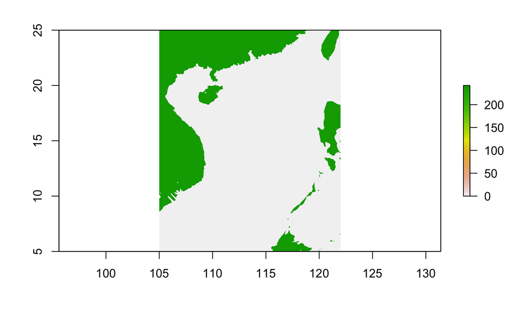

```r
crs(land) <-"+proj=longlat +lat_0=15 +lat_ts=0 +lon_0=113.5 +datum=WGS84"
scs_extent <- extent(105,122,5,25)
extent(land) <- scs_extent
plot(land)
```

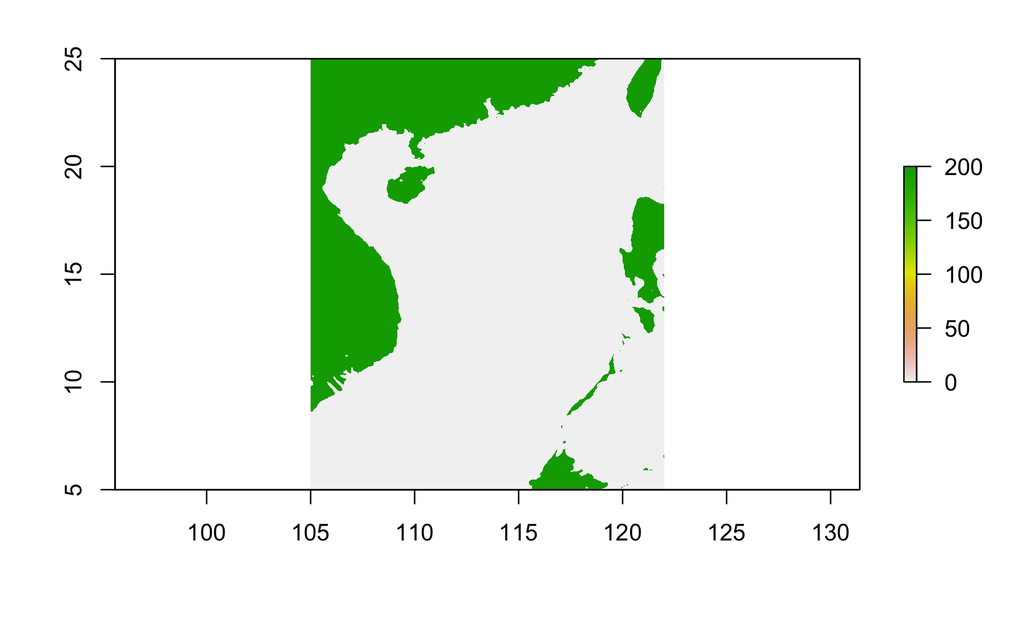

```r
land[land>=50] <- 200
#land[land>1 & land < 50] <- 100
land[land<=50] <- 0
plot(land)
```

```r
writeRaster(land,filename="SCS_land_latlong.rst", format = "IDRISI", overwrite=T)
```

```
class      : RasterLayer
dimensions : 1806, 1533, 2768598  (nrow, ncol, ncell)
resolution : 0.01108937, 0.0110742  (x, y)
extent     : 105, 122, 5, 25  (xmin, xmax, ymin, ymax)
crs        : NA
source     : SCS_land_latlong.rdc
names      : SCS_land
values     : 0, 200  (min, max)
```

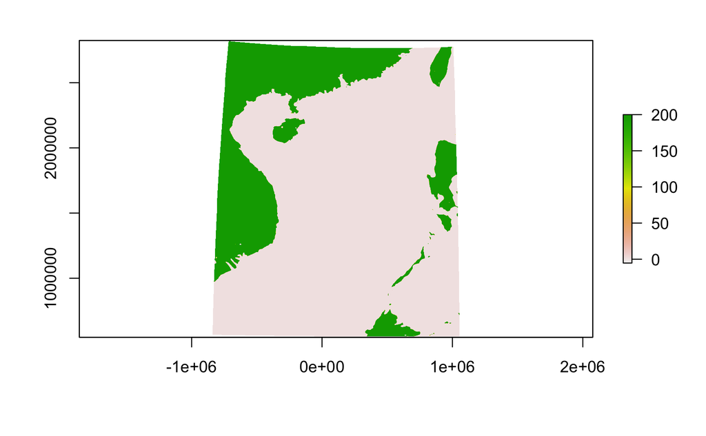

```r
#Project to utm

utmproj <- crs("+proj=utm +zone=50N ")
land_utm <- projectRaster(from=land, crs=utmproj, res = 1000)
plot(land_utm)
```

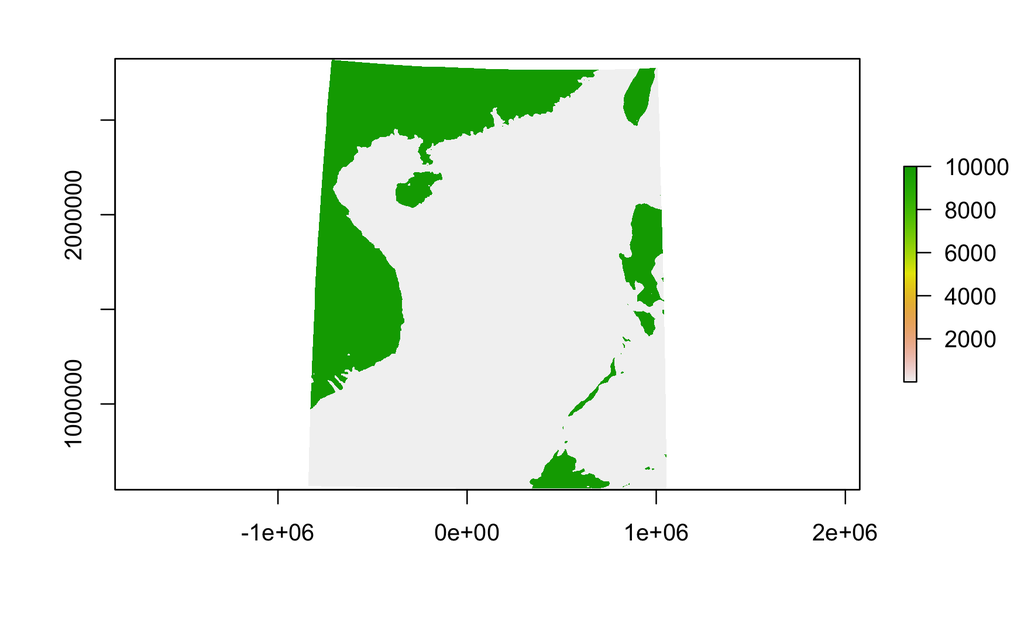

```r
land_utm[land_utm>=50] <- 10000
#land_utm[land_utm>50 & land_utm < 150] <- 100
land_utm[land_utm<=50] <- 1
plot(land_utm)
```

# Using Graphab 2.6

Found this great little [software](http://thema.univ-fcomte.fr/productions/graphab/en-home.html) by Foltete et al. (2012) that does exactly what I want.

1. Create Graph
1. define path
2. import landscape raster (SCS_reefs_utm_1000.rst)
3. select 8-“connexity”, and “100” as habitat patch code.
4. Minimum patch area 25ha
5. Do NOT simplify patch for planar graph
2. Create Linkset
1. Name linkset
2. Select “Complete”, Save Real Path
3. Select maximum distance in km using PLD x avg. current speed in SCS (18.7 km/day)
4. Select cost from raster, use SCS_land_utm_1000.rst
3. Create Graph
1. name graph
2. select appropriate linkset
3. enter same maximum distance as used for linkset
4. include intra-patch distances for metrics
4. Measure local graph metrics
1. Closeness centrality
2. Betweenness centrality 1. measure as “Batch parameter” p = 0.5, beta = 0, from 10km to 200km, by increments of 10km
5. Steps 2-4 for all 9 species. Export attributes table to csv.

Foltête, J.-C., Clauzel, C., & Vuidel, G. (2012). A software tool dedicated to the modelling of landscape networks. Environmental Modelling & Software, 38, 316–327. doi: 10/f4bjvp

```r
BC <- read_delim(file = "./graphab_SCS_cost6/SCS_graph_metrics.txt", delim = "\t")
# rank them
BCrank <- BC %>%  select(starts_with("BC")) %>% transmute_all(desc) %>% transmute_all(rank) %>% rowwise()

meanranks <- BCrank %>% mutate(Ajaponicus=mean(c_across(ends_with("Ajaponicus")))) %>%
                        mutate(Cauriga=mean(c_across(ends_with("Cauriga")))) %>%
                        mutate(Clunulatus=mean(c_across(ends_with("Clunulatus")))) %>%
                        mutate(Cstriatus=mean(c_across(ends_with("Cstriatus")))) %>%
                        mutate(Cvroliki=mean(c_across(ends_with("Cvroliki")))) %>%
                        mutate(Daruanus=mean(c_across(ends_with("Daruanus")))) %>%
                        mutate(Lkasmira=mean(c_across(ends_with("Lkasmira")))) %>%
                        mutate(Nplicata=mean(c_across(ends_with("Nplicata")))) %>%
                        mutate(Pcoelestis=mean(c_across(ends_with("Pcoelestis")))) %>% select(180:188)

 meanranks[14,]
```

| BC_d200000_p0.5_beta0_Pcoelestis | Ajaponicus | Cauriga | Clunulatus | Cstriatus | Cvroliki | Daruanus | Lkasmira | Nplicata |
| --- | --- | --- | --- | --- | --- | --- | --- | --- |
| 6 | 6 | 5 | 5.15 | 6 | 14 | 18 | 6 | 6 |

And now I’m interested in measuring *graph diameter* for each species as well, but Graphab only does so in units of km. So I am going to use igraph to do so in units of steps. Also ended up measuring betweenness centrality with igraph because igraph does it in a more basic understandable way, without weighting by distance and reef capacity for example. I wrote out these results and re-imported them into Graphab (added them to patches.csv) for final visualization.

```r
species <- c("Ajaponicus","Cauriga","Clunulatus","Cstriatus","Cvroliki","Daruanus",
             "Lkasmira","Nplicata","Pcoelestis")
stats <- NULL
names <- "ID"
vertices <- tibble(.rows=115, vertex=1:115)
for(s in species){
  csv <- read_csv(paste0("./graphab_SCS_cost6/",s,"-links.csv"))
  graph <- graph.data.frame(csv[,1:2])
  d <- diameter(graph)
  #betweenness centrality for Dongsha
  BC <-betweenness(graph, directed = F)
  BC <- BC[order(as.numeric(names(BC)))]
  BCdongsha <- BC["14"]
  rank <- rank(desc(betweenness(graph, directed=F)))
  rank <- rank[order(as.numeric(names(rank)))]
  rankdongsha <- rank["14"]
  stats <- rbind(stats,c(diameter=d,dongshaBC=BCdongsha,DongshaBCrank=rankdongsha))
  vertices <- bind_cols(vertices,BC=BC,r=rank)
  names <- c(names,paste0(s,"_BC"),paste0(s,"_rank"))
}
vertices<-setNames(vertices,names)
stats <- cbind(species,stats)

#write_csv(stats,file = "igraph_statistics.csv")
#write_csv(vertices, file = "igraph_vertices.csv")
```